# Ath2

Lieke Vlaar

April 20th 2021

# Introduction

In this file the complete analysis workflow of count data of the Arabidopsis RNAseq experiment is shown.

## Goal

The goal of this experiment is to unravel the effect of solanoeclepin A on the plant. Solanoeclepin A is applied on Arabidopsis seedlings under various nutritional conditions. The set up of this experiment is summarized in this figure:

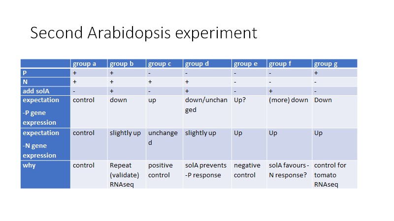

## Setup

Packages necessary:

- Checkpoint
- DESeq2
- dplyr
- tidyr
- tidyverse
- Biostrings
- biomaRt
- biomartr
- clusterProfiler
- org.At.tair.db
- tibble
- mixOmics
- vegan
- apeglm
- EnhancedVolcano
- patchwork

# PCA analysis

Load the function:

```r
source("Ath2/scripts/create_pca_plot.R")
```

Run the function with default settings, which is

```r
plot_pca <- function(count_csv_file = "Ath2/input/counts.csv",
                     xp_design_csv_file = "~Ath2/input/xp_design.csv",
                     pc_x_axis = "PC1",
                     pc_y_axis = "PC2",
                     trm = c("a","b","c","d","e","f","g"),
                     pca_colour = "solA")
```

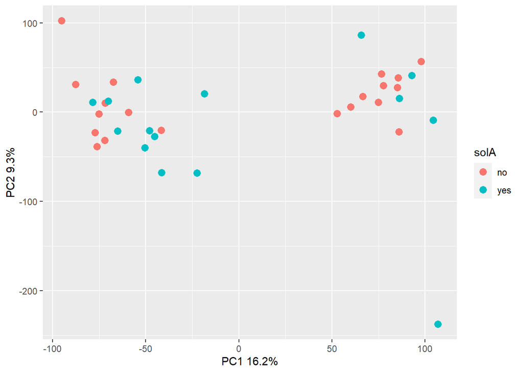

```r
plot_pca()
```

In order to make an overview of what determines the clustering, make the same plot with different colour guides and group them together with patchwork package

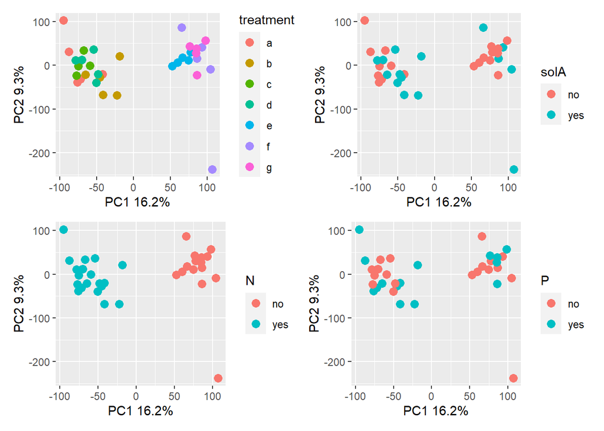

```r
p1 <- plot_pca(pca_colour = "treatment")
p2 <- plot_pca()
p3 <- plot_pca(pca_colour = "N")
p4 <- plot_pca(pca_colour = "P")

(p1 | p2) / (p3 | p4)
```

From this figure, it is clear that the most variation is explained by the N condition. This figure is saved as PCAplot_PC1PC2_allsamples.jpeg.

There is no good separation based on treatment or solA supply. Therefore, check also PC3 and PC4

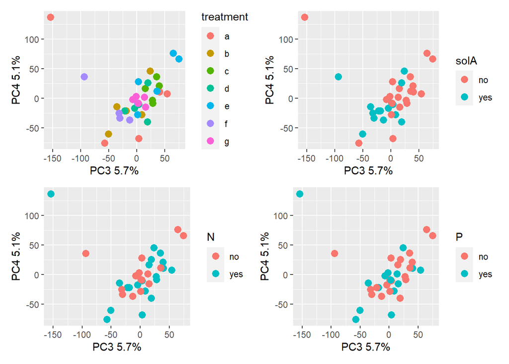

```r
p1 <- plot_pca(pc_x_axis = "PC3", pc_y_axis = "PC4", pca_colour = "treatment")
p2 <- plot_pca(pc_x_axis = "PC3", pc_y_axis = "PC4")
p3 <- plot_pca(pc_x_axis = "PC3", pc_y_axis = "PC4", pca_colour = "N")
p4 <- plot_pca(pc_x_axis = "PC3", pc_y_axis = "PC4", pca_colour = "P")

(p1 | p2) / (p3 | p4)
```

This figure is saved as PCAplot_PC3PC4_allsamples.jpeg

Check the screeplot of all the treatments.

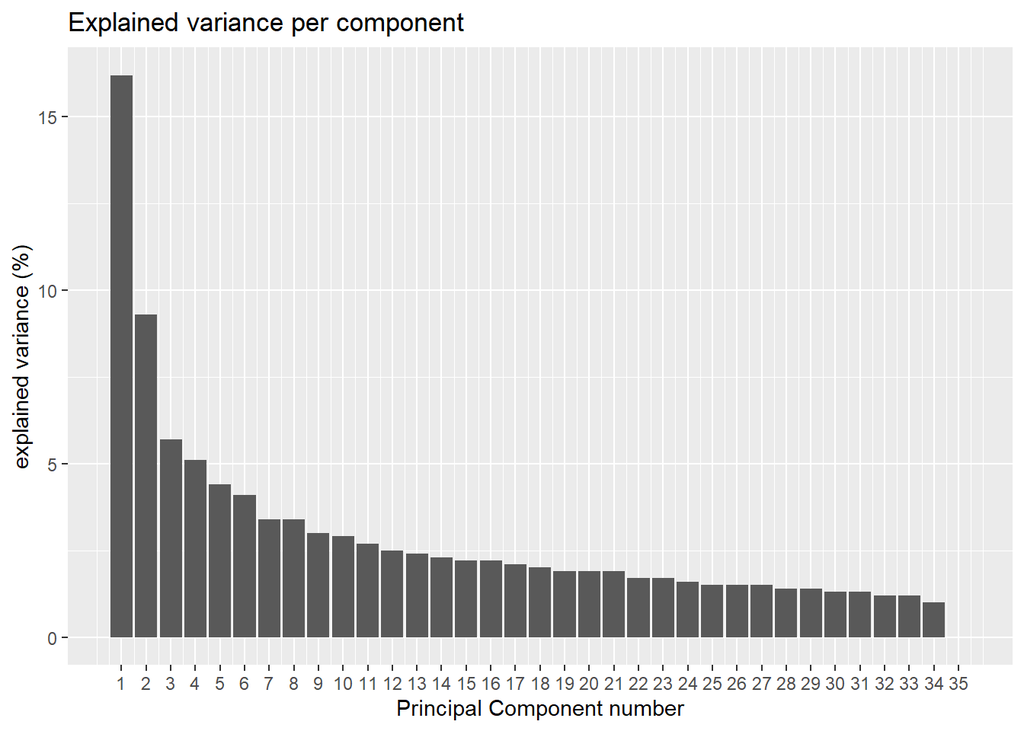

```r
source("Ath2/scripts/scree_plot.R")
plot_scree()
```

Check the histograms of count variability per sample before and after filtering:

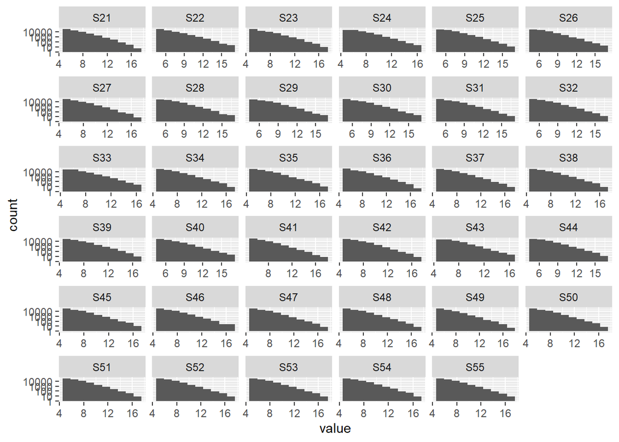

```r
source("Ath2/scripts/produce_scaled_counts_matrix.R")
scaled_counts <- produce_scaled_counts_matrix()

source("Ath2/scripts/filter_counts_based_on_treatment.R")
f <- filter_counts_based_on_treatment()
ft <- f %>% t() %>% as.data.frame() %>% gather ()
ggplot(ft, aes(value)) +
  geom_histogram(bins = 10) +
  facet_wrap(~key, scales = 'free_x') +
  scale_y_log10()
```

```r
f_no_0 <- f[vapply(f,
                   function(z) length(unique(z)) > 1,
                   logical(1L))] %>% data.matrix(., rownames.force = T)

median_all_genes <- median(f_no_0)
median_per_gene <- apply(f_no_0, 2, median)
f_no_0_t <- f_no_0 %>% t() %>% as.data.frame()
f_f <- f_no_0_t %>% filter(median_per_gene > median_all_genes) %>% t() %>% as.data.frame()

f_ft <- f_f %>% t() %>% as.data.frame() %>% gather()
head(f_ft)
```

```
##   key    value
## 1 S21 6.733796
## 2 S21 7.858031
## 3 S21 6.646037
## 4 S21 6.646037
## 5 S21 6.515455
## 6 S21 6.515455
```

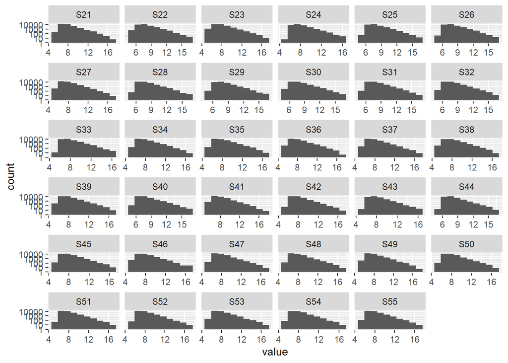

```r
ggplot(f_ft, aes(value)) +
  geom_histogram(bins = 10) +
  facet_wrap(~key, scales = 'free_x') +
  scale_y_log10()
```

These two histograms are saved as histogram_counts_beforefilter.jpeg and histogram_counts_afterfilter.jpeg.

However, this experiment is based on pair-wise comparisons. We have different nutritional conditions (no starvation, only P starvation, N+P starvation) and within these conditions we compare the effect of adding solA. There could be an effect of solA in one condition, but not in the others. Therefore, it makes sense to look whether samples within conditions cluster based on solA treatment.

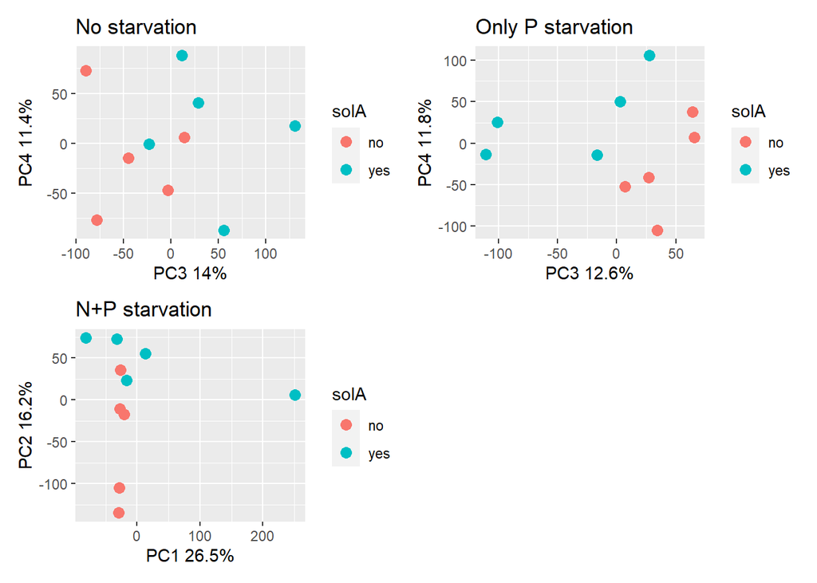

```r
p1 <- plot_pca(pc_x_axis = "PC3", pc_y_axis = "PC4", trm = c("a","b")) + ggtitle("No starvation")
p2 <- plot_pca(pc_x_axis = "PC3", pc_y_axis = "PC4", trm = c("c","d")) + ggtitle("Only P starvation")
p3 <- plot_pca(trm = c("e","f")) + ggtitle("N+P starvation")

p1 + p2 + p3 + plot_layout(ncol = 2)
```

This plot was saved as PCAplots_showing_clustering_solA.jpeg In these plots, the clustering based on solA treatment is better. Especially for N+P starvation, where the clustering is visible on the axis of PC2.

Check scree plot of all nutritional conditions.

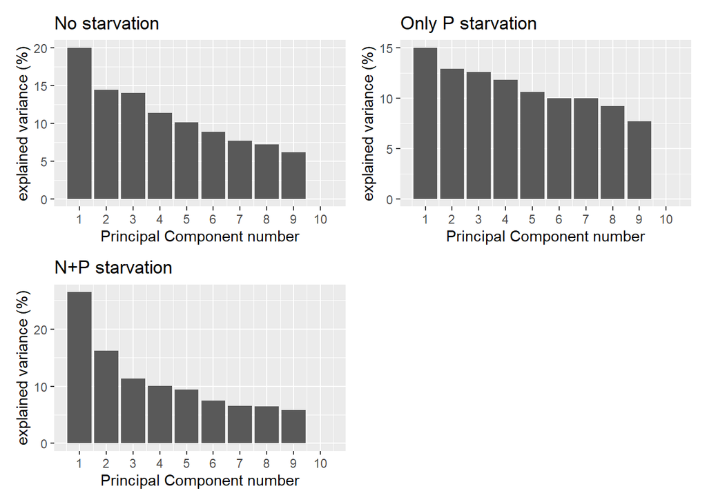

```r
p1 <- plot_scree(trm = c("a","b")) + ggtitle("No starvation")
p2 <- plot_scree(trm = c("c","d")) + ggtitle("Only P starvation")
p3 <- plot_scree(trm = c("e","f")) + ggtitle("N+P starvation")

p1 + p2 + p3 + plot_layout(ncol = 2)
```

# DEG analysis

## Wald test

Taking into account all samples, regardless of nutritional condition, check the amount of DEGs comparing solA yes vs no. The design of the DESeq formula is set to ~ N + P + solA.

```r
source("Ath2/scripts/volcanoplot.R")
```

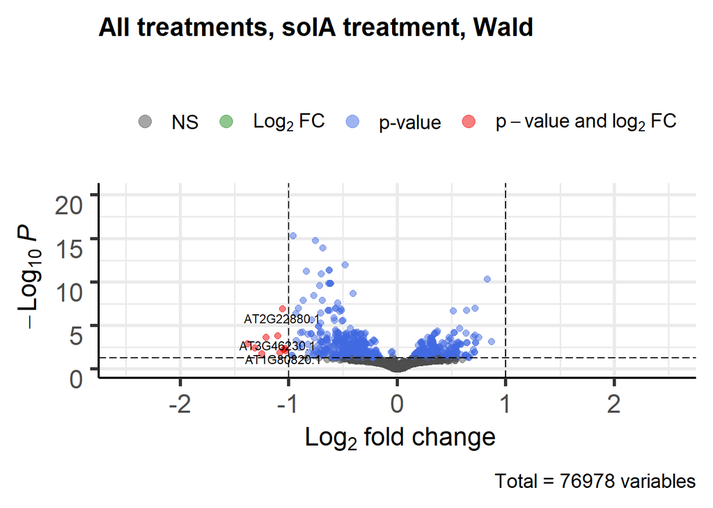

```r
make_volcanoplot(trtm = c("a","b","c","d","e","f","g"), log2FC_threshold = 0, FCcutoff_volcano = 1, padj_threshold = 0.05, ttl = "All treatments, solA treatment, Wald", method = "solA", xsize = 2.5)
```

There are a few significant genes present. We can try to include not only the solA factor in the model, but also the interaction with N, since this factor has a big influence on all samples. Therefore, we set method to N:solA. The design formula now becomes ~N + P + N:solA + solA. The resulting volcanoplot is shown here:

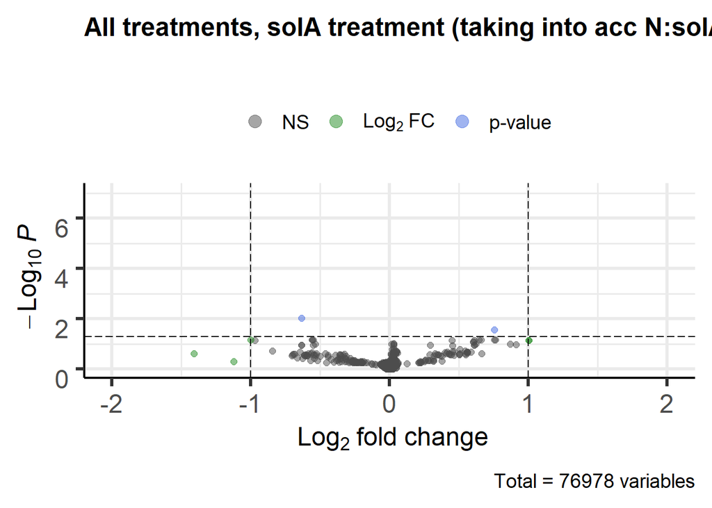

```r
make_volcanoplot(trtm = c("a","b","c","d","e","f","g"), log2FC_threshold = 0, FCcutoff_volcano = 1, padj_threshold = 0.05, ttl = "All treatments, solA treatment (taking into acc N:solA), Wald", method = "N:solA+solA", xsize = 2)
```

It seems that there are no DEGs that are caused by solA alone. So, let’s find out which DEGs come up if we only look at factor N:solA. We can completely and only focus on the N:solA interaction (making the design formula ~N + P + N:solA):

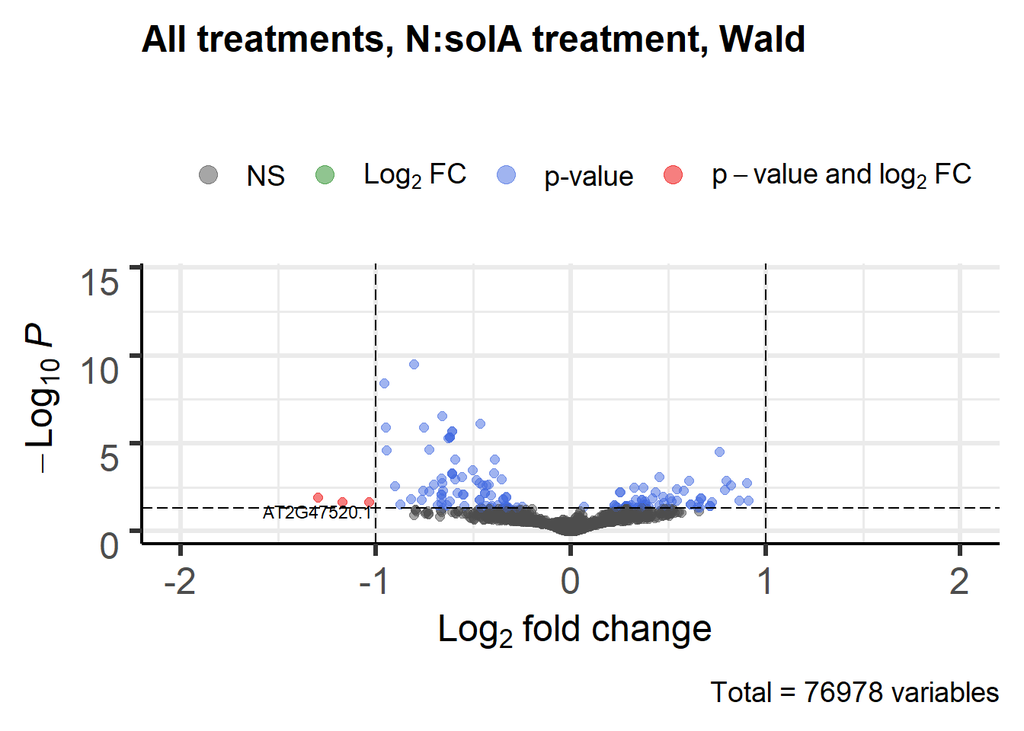

```r
make_volcanoplot(trtm = c("a","b","c","d","e","f","g"), log2FC_threshold = 0, FCcutoff_volcano = 1, padj_threshold = 0.05, ttl = "All treatments, N:solA treatment, Wald", method = "N:solA", xsize = 2)
```

Now there are a few DEGs.

But it probably makes more sense to do the comparison yes/no solA within nutritional conditions.

So, do this analysis for the within nutritional condition comparison. In this case, the design formula is set to ~ treatment (N and P are not relevant anymore - will even give an error - because you compare samples that have the same N and P).

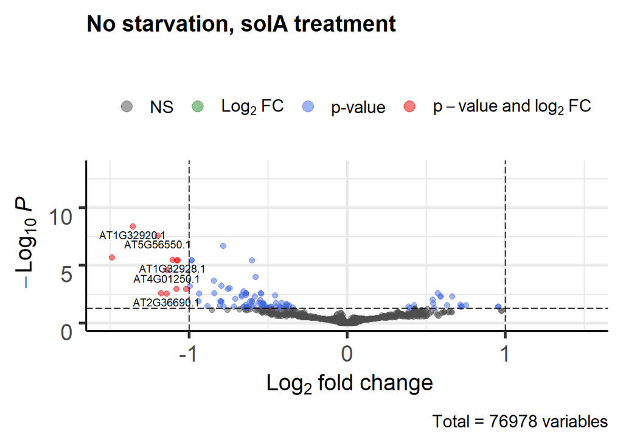

```r
p1 <- make_volcanoplot(log2FC_threshold = 0, FCcutoff_volcano = 1, padj_threshold = 0.05, xsize = 1.5, ttl = "No starvation, solA treatment")
p2 <- make_volcanoplot(trtm = c("c", "d"), ref_treatment = "d", treatment2 = "c", log2FC_threshold = 0, FCcutoff_volcano = 1, padj_threshold = 0.05, xsize = 1.5, ttl = "P starvation, +N, solA treatment")
p3 <- make_volcanoplot(trtm = c("e", "f"), ref_treatment = "f", treatment2 = "e", log2FC_threshold = 0, FCcutoff_volcano = 1, padj_threshold = 0.05, xsize = 1.5, ttl = "N+P starvation, solA treatment")
p1
```

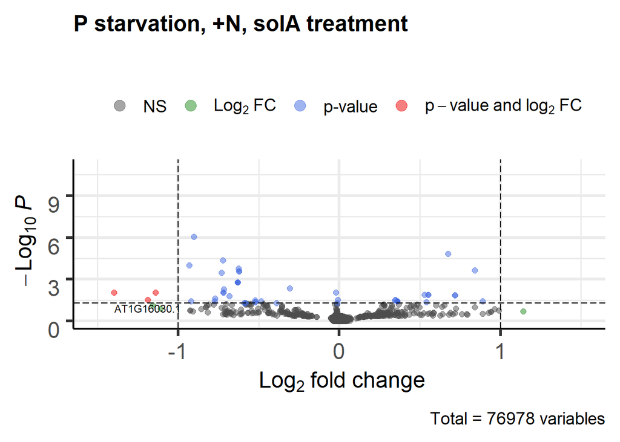

```r
p2
```

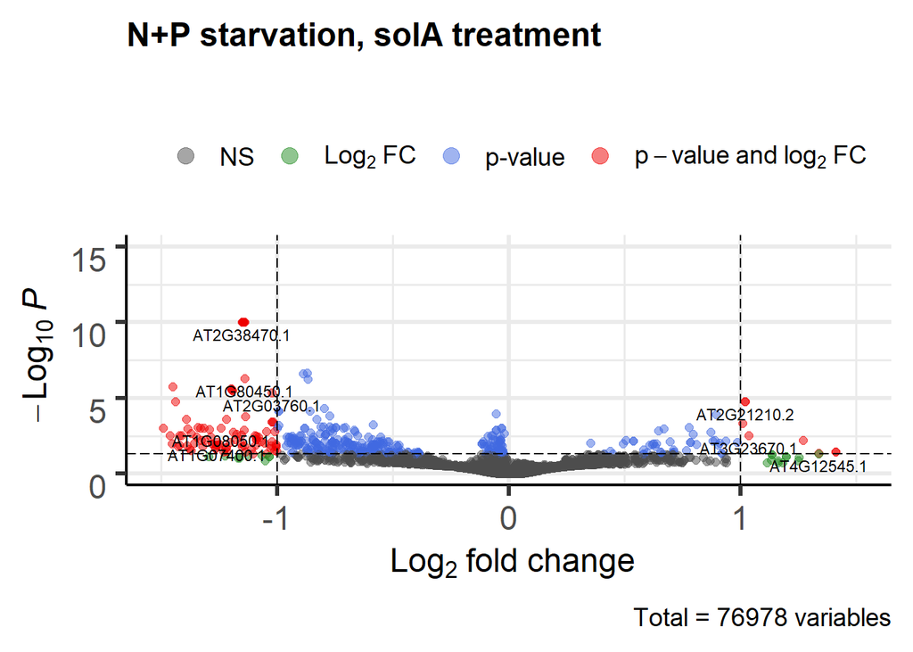

```r
p3
```

There are most DEGs under N+P starvation, followed by No starvation, and then only P starvation.

## Heatmaps

Another way of visualising clustering is with a heatmap. First, we have to extract the list of DEGs, filtered for Padj<0.05. Then we take those vst_transformed counts and plot the heatmap with pheatmap.

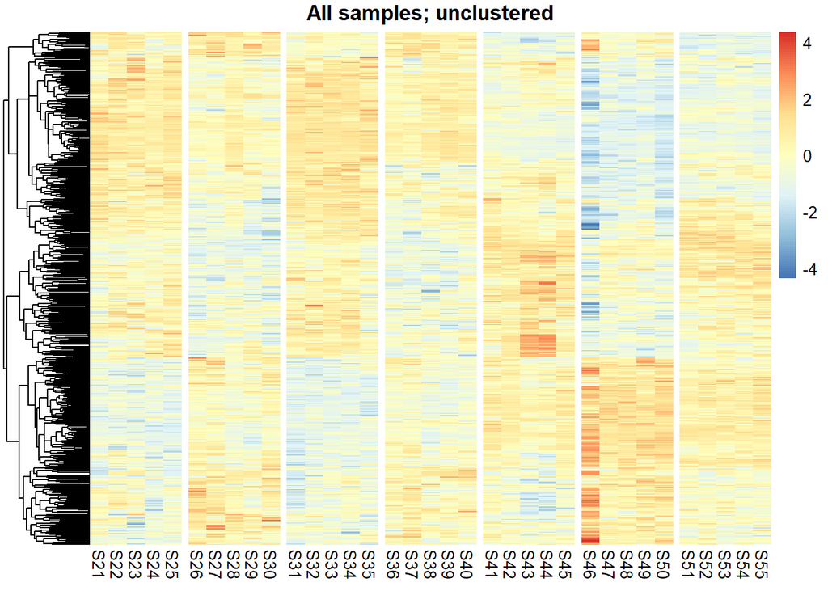

```r
source("Ath2/scripts/get_filtered_list_of_DEGs.R")
x <- get_list_of_DEGs(trtm = c("a","b","c","d","e","f","g"), method = "solA", log2FC_threshold = 0)
x <- x %>% rownames_to_column("genes")
source("Ath2/scripts/produce_scaled_counts_matrix.R")
y <- produce_scaled_counts_matrix() %>% column_to_rownames("sample") %>% t() %>% as.data.frame() %>% rownames_to_column("genes")
DEG_counts <- left_join(x, y, by="genes")
DEG_counts <- DEG_counts[, -c(2,3,4,5,6,7)]
DEG_counts <- DEG_counts %>% column_to_rownames("genes")
xp_design <- xp_design %>% column_to_rownames("sample")
p1 <- pheatmap(DEG_counts,
         gaps_col = c(5,10,15,20,25,30),
         cluster_rows = TRUE,
         cluster_cols = FALSE,
         show_rownames = FALSE,
         show_colnames = TRUE,
         scale = "row",
         main = "All samples; unclustered")
```

[figure not shown]

```r
p2 <- pheatmap(DEG_counts,
         cluster_rows = TRUE,
         cluster_cols = TRUE,
         show_rownames = FALSE,
         show_colnames = TRUE,
         scale = "row",
         main = "All samples; clustered")
p1
p2
```

In the unclustered heatmap, samples are clustered according to sample group (treatment). The treatments with solA are showing an overlapping pattern versus the treatments without solA. In the clustered heatmap, samples are clustered according to similarity in gene expression. In this heatmap it is clear that samples from group f (S46, 47, 48, 49, 50), which is N+P starvation + solA, cluster far away from the rest, including the same nutritional conditions without solA (S41 - S45). Hence, solA treatment mostly affects N+P starved plants.

We can try the same but then with only the genes that are DE according to the model ~N+P+N:solA.

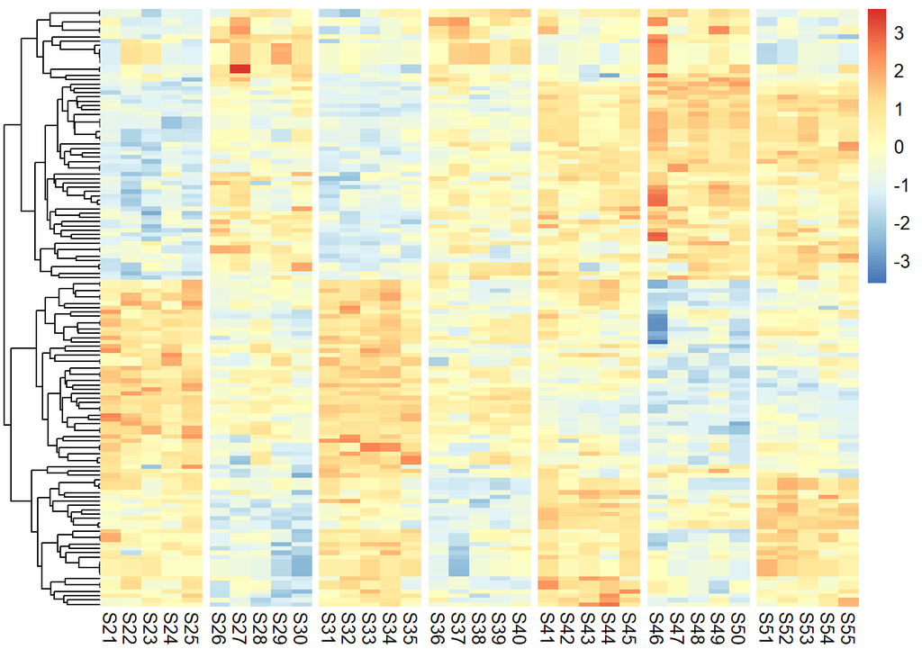

```r
x <- get_list_of_DEGs(trtm = c("a","b","c","d","e","f","g"), method = "N:solA", log2FC_threshold = 0)
x <- x %>% rownames_to_column("genes")

y <- produce_scaled_counts_matrix() %>% column_to_rownames("sample") %>% t() %>% as.data.frame() %>% rownames_to_column("genes")
DEG_counts <- left_join(x, y, by="genes")
DEG_counts <- DEG_counts[, -c(2,3,4,5,6,7)]
DEG_counts <- DEG_counts %>% column_to_rownames("genes")
xp_design <- xp_design %>% column_to_rownames("sample")

pheatmap(DEG_counts,
         gaps_col = c(5,10,15,20,25,30),
         cluster_rows = TRUE,
         cluster_cols = FALSE,
         show_rownames = FALSE,
         show_colnames = TRUE,
         scale = "row",
         border_color = NA)
```

We see roughly the same pattern as in the previous heatmap (p1), but with less genes (since there were less DEGs with this model).

We can also draw the heatmaps for within nutritional conditions. First for the ‘No starvation’ condition.

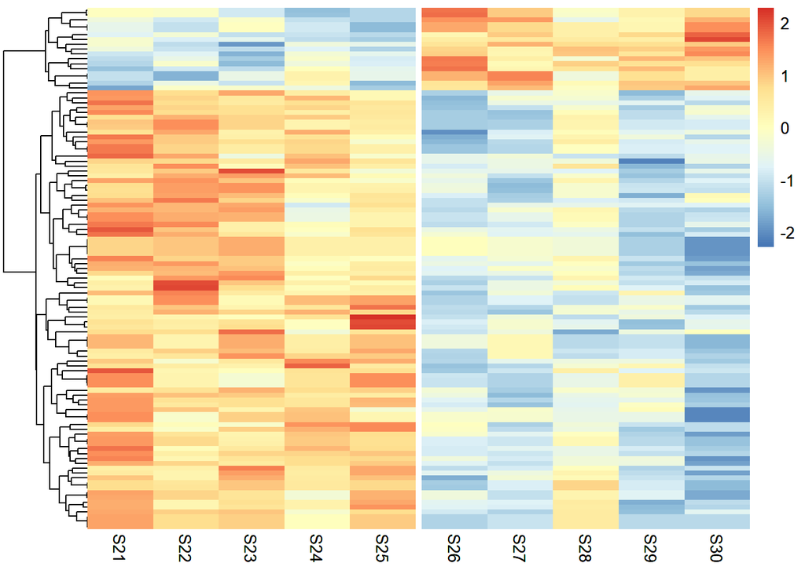

```r
x <- get_list_of_DEGs(trtm = c("a","b"), ref_treatment = "b", treatment2 = "a", method = "treatment", log2FC_threshold = 0)
x <- x %>% rownames_to_column("genes")
source("Ath2/scripts/filter_counts_based_on_treatment.R")
y <- filter_counts_based_on_treatment(tr = c("a","b")) %>% t() %>% as.data.frame() %>% rownames_to_column("genes")

DEG_counts <- left_join(x, y, by="genes")
DEG_counts <- DEG_counts[, -c(2,3,4,5,6,7)]
DEG_counts <- DEG_counts %>% column_to_rownames("genes")
p <- pheatmap(DEG_counts,
         gaps_col = 5,
         cluster_rows = TRUE,
         cluster_cols = FALSE,
         show_rownames = FALSE,
         show_colnames = TRUE,
         scale = "row",
         border_color = NA)
p
```

Then for the ‘Only P starvation’ condition:

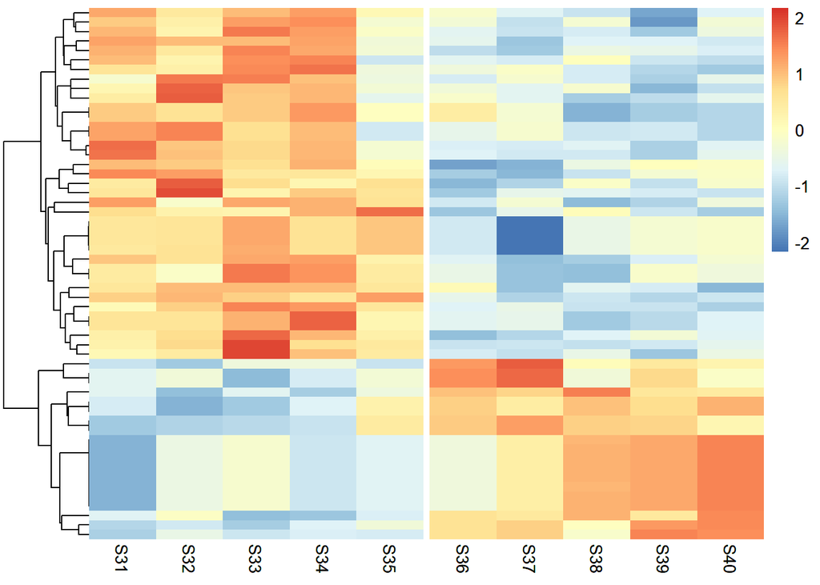

```r
x <- get_list_of_DEGs(trtm = c("c","d"), ref_treatment = "d", treatment2 = "c", method = "treatment", log2FC_threshold = 0)
x <- x %>% rownames_to_column("genes")
source("Ath2/scripts/filter_counts_based_on_treatment.R")
y <- filter_counts_based_on_treatment(tr = c("c","d")) %>% t() %>% as.data.frame() %>% rownames_to_column("genes")

DEG_counts <- left_join(x, y, by="genes")
DEG_counts <- DEG_counts[, -c(2,3,4,5,6,7)]
DEG_counts <- DEG_counts %>% column_to_rownames("genes")
p <- pheatmap(DEG_counts,
         gaps_col = 5,
         cluster_rows = TRUE,
         cluster_cols = FALSE,
         show_rownames = FALSE,
         show_colnames = TRUE,
         scale = "row",
         border_color = NA)
p
```

And lastly, for the “N+P starvation” treatment:

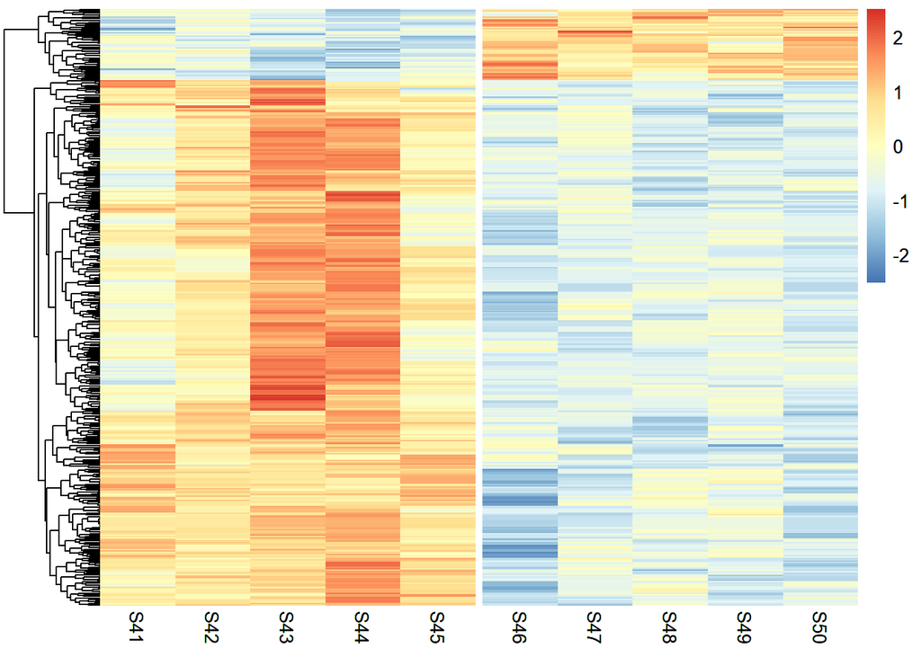

```r
x <- get_list_of_DEGs(trtm = c("e","f"), ref_treatment = "f", treatment2 = "e", method = "treatment", log2FC_threshold = 0)
x <- x %>% rownames_to_column("genes")
source("Ath2/scripts/filter_counts_based_on_treatment.R")
y <- filter_counts_based_on_treatment(tr = c("e","f")) %>% t() %>% as.data.frame() %>% rownames_to_column("genes")

DEG_counts <- left_join(x, y, by="genes")
DEG_counts <- DEG_counts[, -c(2,3,4,5,6,7)]
DEG_counts <- DEG_counts %>% column_to_rownames("genes")
p <- pheatmap(DEG_counts,
         gaps_col = 5,
         cluster_rows = TRUE,
         cluster_cols = FALSE,
         show_rownames = FALSE,
         show_colnames = TRUE,
         scale = "row",
         border_color = NA)
p
```

From these heatmaps it is inferred that the treatment with solA leads mostly to down regulation of genes, in all nutritional conditions.

## Likelihood Ratio Test (LRT)

Let’s compare the DEGs from the Wald test with the LRT (Likelihood Ratio Test) for verification. To start with, let’s take into account all samples and see if LRT detects any DEGs based on solA treatment.

```r
source("Ath2/scripts/compare_Wald_vs_LRT.R")
```

The output table of this function gives all the genes that overlap between the Wald test and LRT. So the number of rows is the number of overlapping genes.The formulae for the LRT are ~N + P (null model) and ~N + P + solA (full model), because we select method = “solA”. This same full model is used for Wald test.

```r
compare_wald_vs_LRT(trtm = c("a","b","c","d","e","f","g"), method = "solA")
```

```
## [1] "LRT gives 844 DEGs, while Wald test gives 866 DEGs."
```

```
## # A tibble: 841 x 7
##    gene                  baseMean log2FoldChange  lfcSE  stat    pvalue     padj
##    <chr>                    <dbl>          <dbl>  <dbl> <dbl>     <dbl>    <dbl>
##  1 AT1G01430.1              477.           0.288 0.0813  3.55   3.92e-4  2.12e-2
##  2 AT1G01448.3               24.8         -0.784 0.242  -3.24   1.19e-3  4.42e-2
##  3 AT1G01448.1               23.4         -0.836 0.234  -3.57   3.56e-4  1.99e-2
##  4 AT1G01448.2               23.3         -0.850 0.239  -3.56   3.65e-4  2.03e-2
##  5 AT1G02610.2              143.          -0.773 0.145  -5.32   1.01e-7  5.81e-5
##  6 AT1G02610.1              135.          -0.776 0.151  -5.15   2.65e-7  9.51e-5
##  7 AT1G02610.3              174.          -0.622 0.124  -5.02   5.11e-7  1.69e-4
##  8 AT1G02610.2,AT1G0261~    106.          -0.620 0.189  -3.29   1.00e-3  3.97e-2
##  9 AT1G02610.2,AT1G0261~     98.8         -0.792 0.169  -4.69   2.70e-6  5.63e-4
## 10 AT1G03220.1             1321.          -0.343 0.0892 -3.85   1.18e-4  9.39e-3
## # ... with 831 more rows
```

Both methods result in around the same number of DEGs and most genes are overlapping, which is a good indication for this model. Let’s see if the other models we used for the Wald test are also verified by LRT. The model ~N+P+N:solA+solA (reduced model ~N+P+N:solA):

```r
compare_wald_vs_LRT(trtm = c("a","b","c","d","e","f","g"), method = "N:solA+solA")
```

This model cannot be evaluated by LRT because it has less than one degree of freedom.

The model ~N+P+N:solA. How many DEGs are caused by the interaction between N and solA? (reduced model ~N+P)

```r
compare_wald_vs_LRT(trtm = c("a","b","c","d","e","f","g"), method = "N:solA")
```

```
## [1] "LRT gives 791 DEGs, while Wald test gives 139 DEGs."
```

```
## # A tibble: 139 x 7
##    gene                 baseMean log2FoldChange  lfcSE  stat      pvalue    padj
##    <chr>                   <dbl>          <dbl>  <dbl> <dbl>       <dbl>   <dbl>
##  1 AT1G02610.2,AT1G026~     98.8         -0.800 0.217  -3.68 0.000235    4.63e-2
##  2 AT1G14200.1             282.           0.560 0.141   3.96 0.0000744   2.33e-2
##  3 AT1G21000.1             413.          -0.378 0.0897 -4.22 0.0000248   1.12e-2
##  4 AT1G21000.2             413.          -0.377 0.0898 -4.20 0.0000270   1.18e-2
##  5 AT1G21010.1             112.          -0.732 0.154  -4.75 0.00000203  1.73e-3
##  6 AT1G22882.1             367.           0.363 0.0939  3.86 0.000112    3.20e-2
##  7 AT1G23390.1            4953.          -0.381 0.0782 -4.87 0.00000112  1.13e-3
##  8 AT1G23710.1             274.          -0.665 0.131  -5.09 0.000000359 4.89e-4
##  9 AT1G25400.1            1218.          -0.756 0.176  -4.30 0.0000171   8.17e-3
## 10 AT1G25400.2            1216.          -0.757 0.176  -4.31 0.0000165   8.01e-3
## # ... with 129 more rows
```

LRT gives many more DEGs but all of the Wald test are in this list. So this model gives us a reliable set of DEGs.

Let’s do the same for the pairwise comparisons within the nutritional conditions. The formulae for the LRT are ~1 (null model) and ~treatment (full model), because we select method = “treatment”. This same full model is used for the Wald test.

```r
#for no starvation:
compare_wald_vs_LRT(trtm = c("a","b"), method = "treatment")
```

```
## [1] "LRT gives 107 DEGs, while Wald test gives 107 DEGs."
```

```
## # A tibble: 107 x 7
##    gene                   baseMean log2FoldChange lfcSE  stat    pvalue     padj
##    <chr>                     <dbl>          <dbl> <dbl> <dbl>     <dbl>    <dbl>
##  1 AT1G13245.1               1464.         -0.461 0.124 -3.73   1.89e-4  3.52e-2
##  2 AT1G13260.1                590.         -0.662 0.151 -4.40   1.10e-5  4.80e-3
##  3 AT1G14200.1                306.          0.747 0.169  4.42   9.72e-6  4.47e-3
##  4 AT1G15040.1               1739.         -0.637 0.170 -3.73   1.88e-4  3.52e-2
##  5 AT1G15040.2               1739.         -0.636 0.170 -3.74   1.85e-4  3.52e-2
##  6 AT1G21400.3,AT1G21400~    1409.         -0.580 0.154 -3.78   1.60e-4  3.44e-2
##  7 AT1G21400.6,AT1G21400~    1407.         -0.583 0.155 -3.76   1.70e-4  3.52e-2
##  8 AT1G23390.1               4472.         -0.417 0.114 -3.66   2.52e-4  4.18e-2
##  9 AT1G25400.1               1294.         -1.05  0.175 -5.99   2.13e-9  3.52e-6
## 10 AT1G25400.2               1292.         -1.05  0.175 -6.00   1.95e-9  3.52e-6
## # ... with 97 more rows
```

```r
#for only P starvation:
compare_wald_vs_LRT(trtm = c("c","d"), ref_treatment = "c", treatment2 = "d", method = "treatment")
```

```
## [1] "LRT gives 50 DEGs, while Wald test gives 56 DEGs."
```

```
## # A tibble: 50 x 7
##    gene        baseMean log2FoldChange lfcSE  stat   pvalue        padj
##    <chr>          <dbl>          <dbl> <dbl> <dbl>    <dbl>       <dbl>
##  1 AT1G16030.1     67.9         -1.37  0.331 -4.14 3.41e- 5 0.0302
##  2 AT1G25560.1    606.          -0.949 0.143 -6.61 3.80e-11 0.000000913
##  3 AT1G27730.1    668.          -0.773 0.134 -5.78 7.32e- 9 0.0000427
##  4 AT1G28190.1     96.6         -0.897 0.220 -4.08 4.48e- 5 0.0363
##  5 AT1G56250.1     27.1         -2.47  0.593 -4.16 3.22e- 5 0.0302
##  6 AT1G68840.1    900.          -0.672 0.123 -5.48 4.20e- 8 0.000175
##  7 AT1G68840.2    375.          -0.565 0.140 -4.03 5.50e- 5 0.0383
##  8 AT2G03760.1    782.          -0.797 0.170 -4.68 2.94e- 6 0.00504
##  9 AT2G23130.1    595.           0.814 0.187  4.35 1.36e- 5 0.0141
## 10 AT2G23130.2    595.           0.814 0.187  4.35 1.36e- 5 0.0141
## # ... with 40 more rows
```

```r
#for N+P starvation:
compare_wald_vs_LRT(trtm = c("e","f"), ref_treatment = "e", treatment2 = "f", method = "treatment")
```

```
## [1] "LRT gives 432 DEGs, while Wald test gives 462 DEGs."
```

```
## # A tibble: 432 x 7
##    gene        baseMean log2FoldChange lfcSE  stat      pvalue     padj
##    <chr>          <dbl>          <dbl> <dbl> <dbl>       <dbl>    <dbl>
##  1 AT1G01560.3     8.66         -4.45  1.06  -4.18 0.0000298   0.00683
##  2 AT1G01560.2     8.37         -5.34  1.22  -4.37 0.0000124   0.00367
##  3 AT1G01560.1     8.66         -4.45  1.06  -4.18 0.0000298   0.00683
##  4 AT1G01560.4     8.37         -5.34  1.22  -4.37 0.0000124   0.00367
##  5 AT1G02610.2   139.           -0.994 0.280 -3.55 0.000390    0.0385
##  6 AT1G02610.1   131.           -1.00  0.278 -3.61 0.000303    0.0333
##  7 AT1G05575.1    73.7          -1.16  0.329 -3.53 0.000410    0.0396
##  8 AT1G07135.1  1691.           -0.799 0.198 -4.04 0.0000538   0.00972
##  9 AT1G07160.1    25.5          -2.51  0.490 -5.11 0.000000318 0.000296
## 10 AT1G07400.1    71.2          -1.46  0.355 -4.11 0.0000391   0.00795
## # ... with 422 more rows
```

For the ‘No starvation’ treatment, there is no difference at all between LRT and Wald test. For the “only P starvation” treatment, there is only a small difference. For the “N+P starvation” treatment, the total DEGs is highest and 30 more DEGs are found with the Wald test, and overlap is high. Let’s visualize these results in a bar plot:

```r
samples <- c("all samples, ~N+P+solA","all samples, ~N+P+N:solA" ,"no starvation","only P starvation","N+P starvation")
Wald <- c(866,139,107,56,462)
LRT <- c(844,791,107,50,432)
overlap <- c(841,139,107,50,432)
x <- data.frame(samples, Wald, LRT, overlap)
x <- melt(x)
```

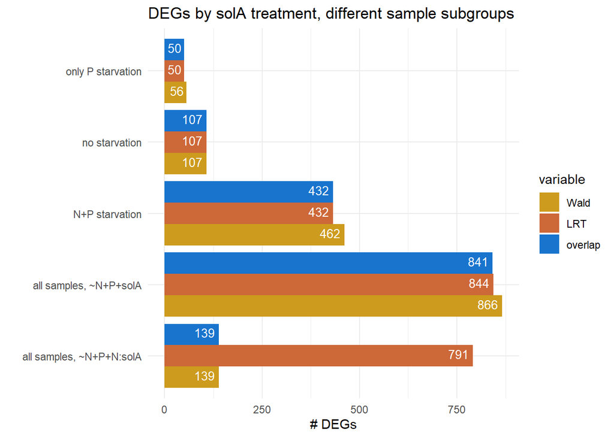

```r
ggplot(data = x,
       aes(x = samples, y = value, fill = variable)) +
  geom_bar(position = "dodge",
           stat = "identity") +
  ggtitle("DEGs by solA treatment, different sample subgroups") +
  xlab("") +
  ylab("# DEGs") +
  theme_minimal() +
  scale_fill_manual(values = c("goldenrod3","sienna3","dodgerblue3")) +
  coord_flip() +
  geom_text(aes(label=value),
            position = position_dodge(width = 0.9),
            vjust = 0.3,
            hjust = 1.2,
            color="white",
            size=3.5)
```

# Annotation of DEGs

Start with annotating the list of DEGs of each subset.

```r
source("Ath2/scripts/get_annotated_DEGs.R")
```

The .csv file will be written to Ath2/outputs/annotated_DEGslist.csv

```r
x <- get_annotated_DEGs(trtm = c("a","b","c","d","e","f","g"), method = "solA")
head(x)
```

```
##    transcript  baseMean log2FoldChange      lfcSE      stat       pvalue
## 1 AT1G01430.1 477.37289      0.2883082 0.08132269  3.545237 3.922609e-04
## 2 AT1G01448.3  24.75324     -0.7836534 0.24177623 -3.241234 1.190134e-03
## 3 AT1G01448.1  23.43804     -0.8358534 0.23410732 -3.570385 3.564563e-04
## 4 AT1G01448.2  23.31642     -0.8504512 0.23861694 -3.564086 3.651269e-04
## 5 AT1G02610.2 143.31944     -0.7725615 0.14509717 -5.324442 1.012632e-07
## 6 AT1G02610.2 143.31944     -0.7725615 0.14509717 -5.324442 1.012632e-07
##           padj      gene tair_symbol uniprotswissprot entrezgene_id
## 1 2.121705e-02 AT1G01430       TBL25           Q84JH9        837247
## 2 4.419207e-02 AT1G01448        <NA>             <NA>            NA
## 3 1.993314e-02 AT1G01448        <NA>             <NA>            NA
## 4 2.025281e-02 AT1G01448        <NA>             <NA>            NA
## 5 5.806468e-05 AT1G02610                                     837915
## 6 5.806468e-05 AT1G02610                                     837915
##                                                                          description
## 1              Mannan O-acetyltransferase 3 [Source:UniProtKB/TrEMBL;Acc:A0A346P850]
## 2                                                                               <NA>
## 3                                                                               <NA>
## 4                                                                               <NA>
## 5 RING/FYVE/PHD zinc finger superfamily protein [Source:UniProtKB/TrEMBL;Acc:F4HXK4]
## 6 RING/FYVE/PHD zinc finger superfamily protein [Source:UniProtKB/TrEMBL;Acc:F4HXK4]
##   external_gene_name external_gene_source
## 1              TBL25  UniProtKB Gene Name
## 2               <NA>                 <NA>
## 3               <NA>                 <NA>
## 4               <NA>                 <NA>
## 5
## 6
```

Then, let’s see if there are any GO terms enriched for these genes. The .csv file with all GO terms will be written to Ath2/outputs/GOannotationslist.csv

```r
source("Ath2/scripts/GO_annotation_list.R")
```

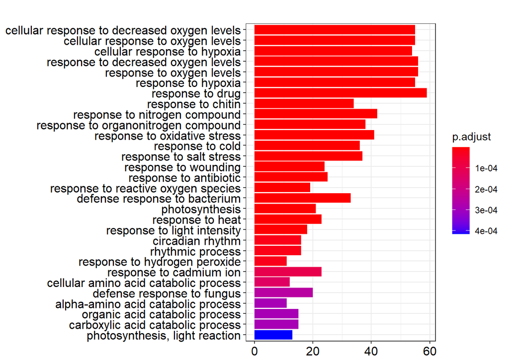

```r
g <-GO_annotation_list(trtm = c("a","b","c","d","e","f","g"), method = "solA", plottype = "bar")
g
```

It is also possible to see the relationships between GO terms that are enriched:

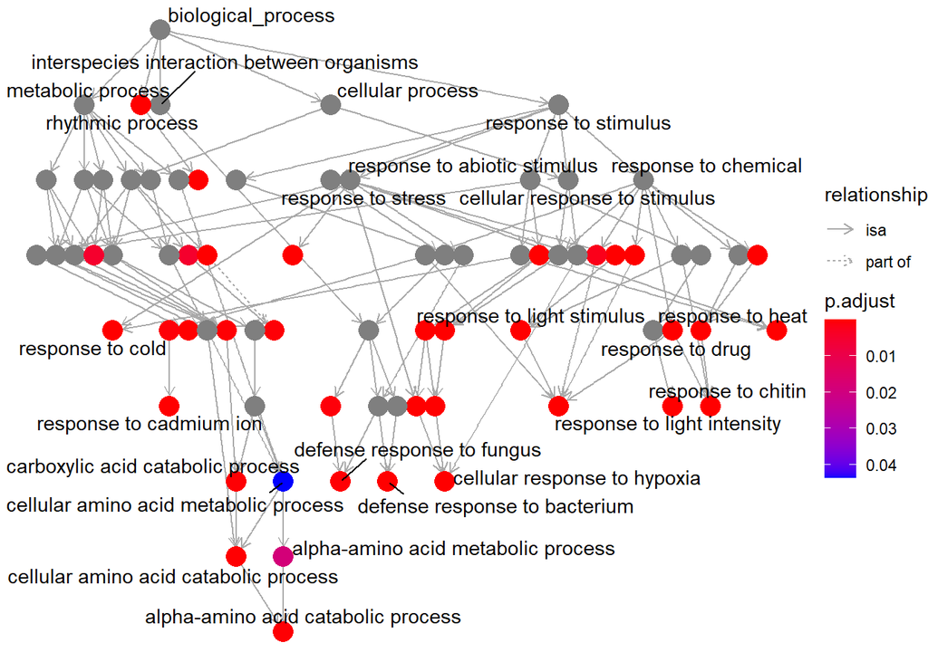

```r
GO_annotation_list(trtm = c("a","b","c","d","e","f","g"), method = "solA", plottype = "go")
```

Let’s also do the annotation and GO term annotation of the DEGs we found when using other models and subsets of samples. First, the DEGs we find when using the N:solA term instead of solA term.

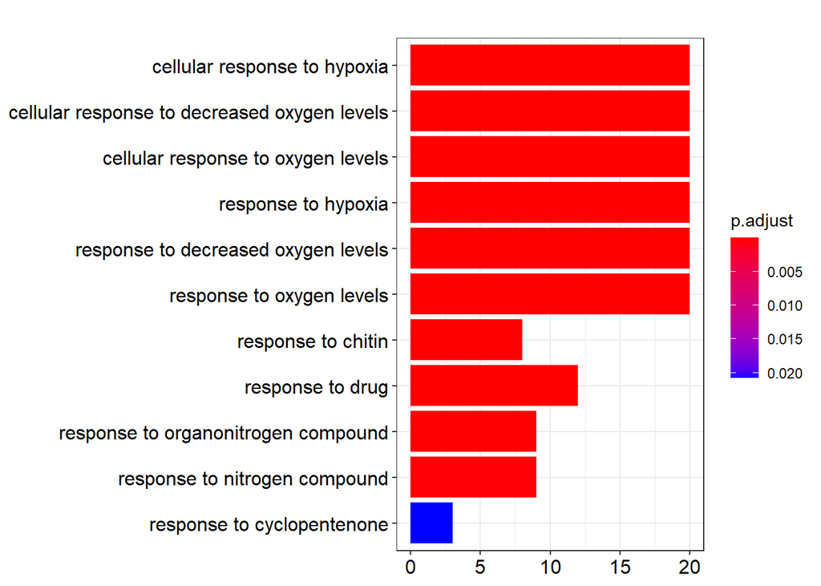

```r
x <- get_annotated_DEGs(trtm = c("a","b","c","d","e","f","g"), method = "N:solA")
GO_annotation_list(trtm = c("a","b","c","d","e","f","g"), method = "N:solA", plottype = "bar")
```

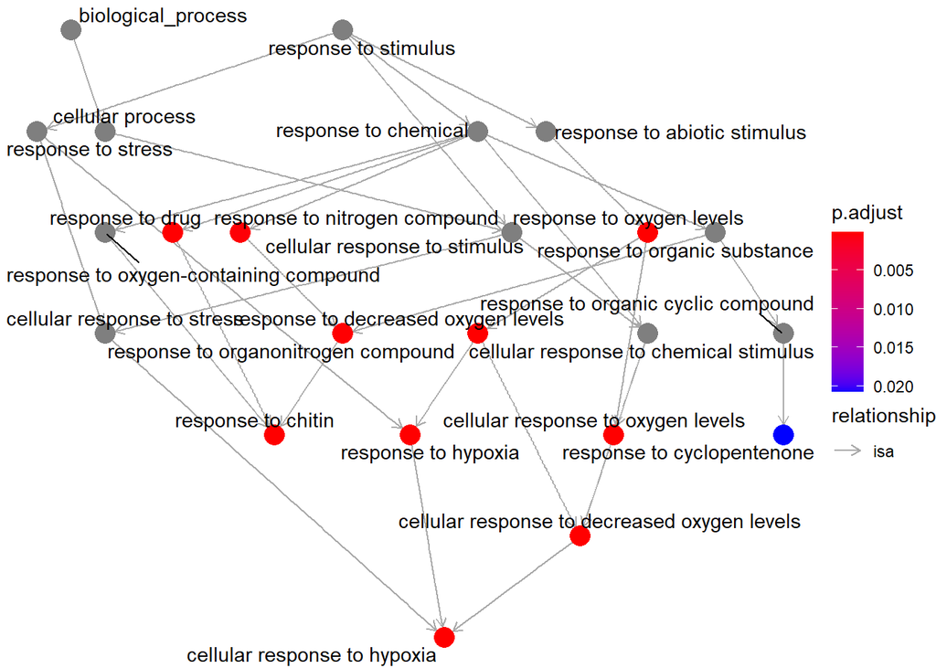

```r
GO_annotation_list(trtm = c("a","b","c","d","e","f","g"), method = "N:solA", plottype = "go")
```

Then, do the same for all the comparisons within nutritional conditions:

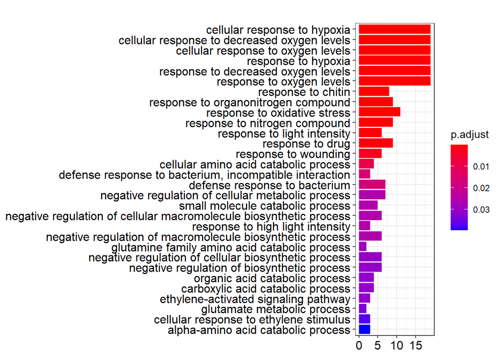

```r
#for the non starvation samples
x <- get_annotated_DEGs(trtm = c("a","b"), method = "treatment")
GO_annotation_list(trtm = c("a","b"), method = "treatment", plottype = "bar")
```

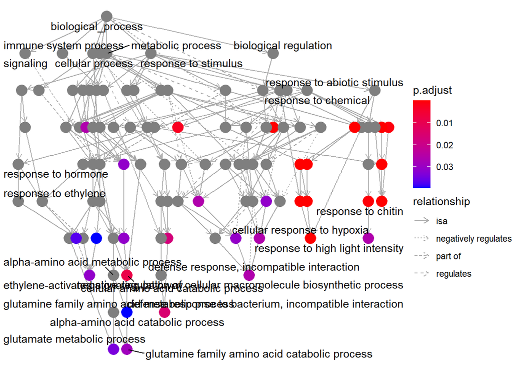

```r
GO_annotation_list(trtm = c("a","b"), method = "treatment", plottype = "go")
```

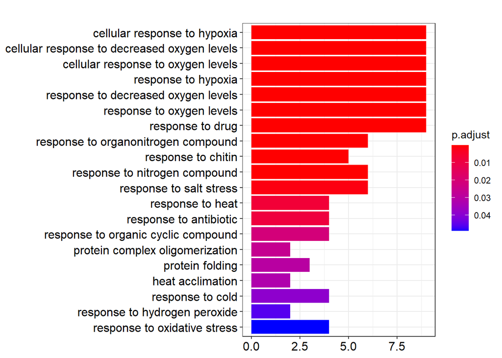

```r
#for the only P starvation samples
x <- get_annotated_DEGs(trtm = c("c","d"), ref_treatment = "c", treatment2 = "d", method = "treatment")
GO_annotation_list(trtm = c("c","d"), ref_treatment = "c", treatment2 = "d", method = "treatment", plottype = "bar")
```

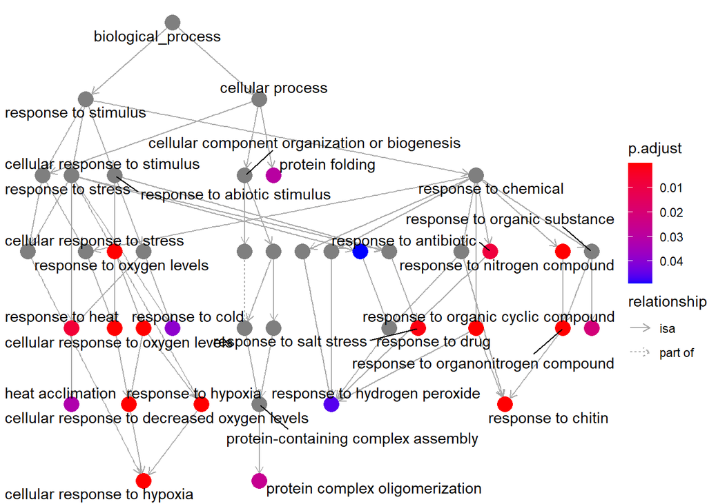

```r
GO_annotation_list(trtm = c("c","d"), ref_treatment = "c", treatment2 = "d", method = "treatment", plottype = "go")
```

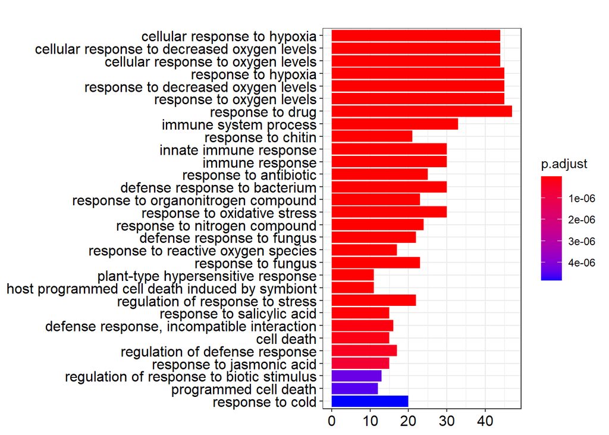

```r
#for the N+P starvation samples
x <- get_annotated_DEGs(trtm = c("e","f"), ref_treatment = "e", treatment2 = "f", method = "treatment")
GO_annotation_list(trtm = c("e","f"), ref_treatment = "e", treatment2 = "f", method = "treatment", plottype = "bar")
```

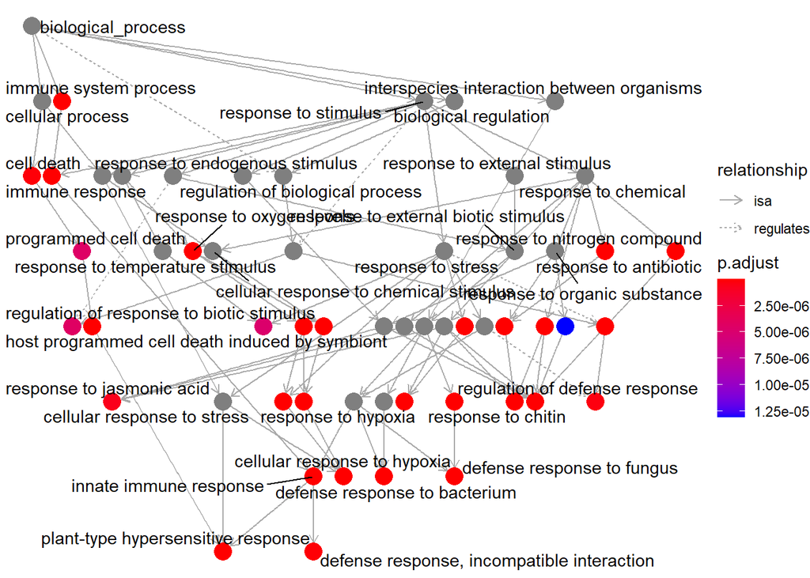

```r
GO_annotation_list(trtm = c("e","f"), ref_treatment = "e", treatment2 = "f", method = "treatment", plottype = "go")
```